# p8105_hw1_sl5454

Sining Leng

2024-09-17

```r
library(tidyverse)
```

##Problem 1

```r
data("penguins", package = "palmerpenguins")

num_row = nrow(penguins)
num_col = ncol(penguins)
mean_flipper_length = mean(penguins$flipper_length_mm, na.rm = TRUE)
summary(penguins)
```

```
##       species          island    bill_length_mm  bill_depth_mm
##  Adelie   :152   Biscoe   :168   Min.   :32.10   Min.   :13.10
##  Chinstrap: 68   Dream    :124   1st Qu.:39.23   1st Qu.:15.60
##  Gentoo   :124   Torgersen: 52   Median :44.45   Median :17.30
##                                  Mean   :43.92   Mean   :17.15
##                                  3rd Qu.:48.50   3rd Qu.:18.70
##                                  Max.   :59.60   Max.   :21.50
##                                  NA's   :2       NA's   :2
##  flipper_length_mm  body_mass_g       sex           year
##  Min.   :172.0     Min.   :2700   female:165   Min.   :2007
##  1st Qu.:190.0     1st Qu.:3550   male  :168   1st Qu.:2007
##  Median :197.0     Median :4050   NA's  : 11   Median :2008
##  Mean   :200.9     Mean   :4202                Mean   :2008
##  3rd Qu.:213.0     3rd Qu.:4750                3rd Qu.:2009
##  Max.   :231.0     Max.   :6300                Max.   :2009
##  NA's   :2         NA's   :2
```

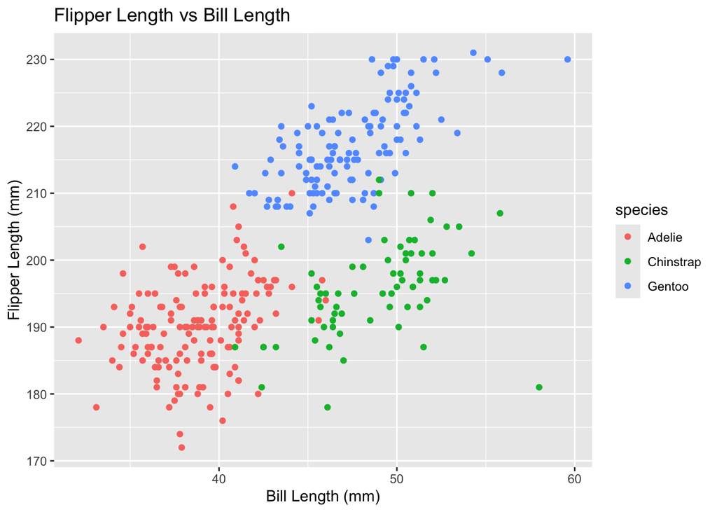

```r
ggplot(penguins, aes(x = bill_length_mm, y = flipper_length_mm, color = species)) +
  geom_point() +
  labs(title = "Flipper Length vs Bill Length",
       x = "Bill Length (mm)",
       y = "Flipper Length (mm)")
```

```r
ggsave("flipper_vs_bill_scatterplot.pdf")
```

The penguins data set contains observations of three species of penguins collected from three islands.The data set includes sex, years, and various physical measurements of the penguins, such as flipper length, which has an average value of 200.9152.The dataset consists of 344 rows and 8 columns, but some measurements contain missing data.

##Problem 2

```r
p2_df =
  tibble(
    sample = rnorm(n = 10),
    log_samp = sample > 0,
    char_vector = sample(letters, 10, replace = TRUE),
    f_vector = factor(sample(c("level1", "level2", "level3"), 10, replace = TRUE))
  )

sample_vec = pull(p2_df, sample)
mean_samp = mean(sample_vec)

log_samp_vec = pull(p2_df, log_samp)
mean_log = mean(log_samp_vec)

char_vec = pull(p2_df, char_vector)
mean_char = mean(char_vec)
f_vec = pull(p2_df, f_vector)
mean_fact = mean(f_vec)
```

The mean of a random sample can be calculated because they are numerical vectors. Since “TRUE” is treated as 1 and “FALSE” as 0 in R, calculating the mean of a logical vector is also valid and gives the proportion of “TRUE” values. The mean of a character vector can’t be calculated because it is a text data. The mean of a factor vector with 3 different factor “levels” can’t be calculated because factors are categorical, not numerical data.

```r
num_log = as.numeric(p2_df[["log_samp"]])
num_char = as.numeric(p2_df[["char_vector"]])
num_f = as.numeric(p2_df[["f_vector"]])
```

The “as.numeric” function converts logical values to numbers as below: “TRUE” becomes “1”, and “FALSE” becomes “0” This conversion works because logical values are binary. The means can be calulated after the conversion and the result represents the proportion of “TRUE” in the vector.

The “as.numeric” function converts character vectors to “NA” because a character can’t be represented by numbers. Thus, calculating the mean of character vectors will fail or produce “NA”.

The “as.numeric” function converts levels of factor vectors to corresponding numbers as follows: “level 1” becomes “1” “level 2” becomes “2” “level 3” becomes “3” This conversion works because different levels can indicated by numbers. However, these numbers don’t have the same meanings as factor levels do. Thus, the means of factor vectors is not meaningful.